# Analysis related to Figure 2

Alejandro Reyes

2017

#### Package

HumanDEU 0.0.99

# 1 Exon statistics

We attach the libraries needed for this vignette. We also load the data object containing gene and transcript annotations.

```r
library(HumanDEU)
library(scales)
library(DEXSeq)
library(matrixStats)
library(dplyr)
library(cowplot)
library(MatchIt)
library(xtable)
library(VennDiagram)
library(gridExtra)


data("dxdObjects", "geneInfo", "transcriptInfo")
```

The code below displays the number of exonic regions from multi-exonic genes, including those from protein-coding genes.

```r
numberOfSamples <- length( unique( c( unique( as.character( colData(dxd1)$sample ) ),
                  unique( as.character( colData(dxd2)$sample ) ),
                  unique( as.character( colData(dxd3)$sample ) ) ) ) )
numberOfSamples
```

```
## [1] 798
```

```r
multiExonicGenes <- ( as.data.frame( mcols(dxd1) ) %>%
                         dplyr:::count(groupID) %>%
                         filter( n > 1 ) )$groupID

numberExons <- nrow( filter( as.data.frame(mcols(dxd1)),
                            groupID %in% multiExonicGenes ) )
numberExons
```

```
## [1] 499667
```

```r
proteinCodingGenes <- filter( geneInfo,
                             gene_biotype == "protein_coding" )$ensembl_gene_id

length( intersect( multiExonicGenes, proteinCodingGenes ) )
```

```
## [1] 18295
```

```r
nrow( filter( as.data.frame( mcols(dxd1 ) ),
             groupID %in% multiExonicGenes,
             groupID %in% proteinCodingGenes ) )
```

```
## [1] 412116
```

Next, we load the of the precomputed objects and format them in a ‘tidy’ data frame that summarized the statistics for each exonic region in each subset of the *GTEx* data.

```r
data( "crossCoefs1", "crossCoefs2", "crossCoefs3",
      "pvals1", "pvals2", "pvals3",
      "dxdJRObjects", "dsdObjects" )

getResultsDF <- function( crossCoefs, dxd, dxdJR, pvals, label="" ){
    tdu <- unlist( lapply(seq_len(dim(crossCoefs)[1]), function(i){
               max(abs( colMedians( (crossCoefs[i,,] - mean(crossCoefs[i,,]) ) / sd(crossCoefs[i,,]) ) ) )
           }) )
    #tdu2 <- unlist( lapply(seq_len(dim(crossCoefs)[1]), function(i){
    #max(abs( colMedians( crossCoefs[i,,] ) ) )
    #}) )
    sds <- unlist( lapply(seq_len(dim(crossCoefs)[1]), function(i){
               sd( crossCoefs[i,,] )
           }) )
    names(tdu) <- dimnames(crossCoefs)[["exon"]]
#    names(tdu2) <- dimnames(crossCoefs)[["exon"]]
    names(sds) <- dimnames(crossCoefs)[["exon"]]
    rMeans <- rowMeans( counts( dxd, normalized=TRUE )[,colData(dxd)$exon=="this"] )
    oMeans <- rowMeans( counts( dxdJR, normalized=TRUE )[,colData(dxdJR)$exon=="others"] )
    nameList <- strsplit(rownames(dxd), ":")
    df <- data.frame(
        gene=sapply( nameList, "[[", 1),
        exon=sapply( nameList, "[[", 2),
        mean=rMeans,
        esMeans=oMeans,
        tdu=tdu,
        #tduR=tdu2,
        sds=sds,
        pvals=pvals, label=label)
      #   df$pvals[rMeans < 10] <- NA
    df$padj <- p.adjust( df$pvals, method="BH" )
    df
}

path <- system.file("data", package="HumanDEU")

fl <- file.path( path, "resultsDF.RData" )

if( !file.exists( fl ) ){
    resultsDF <- rbind(
        getResultsDF( crossCoefs1, dxd1, dxd1JR, pvalsTissues1, label="subsetA" ),
        getResultsDF( crossCoefs2, dxd2, dxd2JR, pvalsTissues2, label="subsetB" ),
        getResultsDF( crossCoefs3, dxd3, dxd3JR, pvalsTissues3, label="subsetC" ) )
    save( resultsDF, file="../data/resultsDF.RData")
}else{
    load(fl)
}

getDEUNumbers <- function( lab, dfFun, returnEx=FALSE ){
    df <- filter( dfFun,
                 label %in% lab,
                 padj < 0.1,
                 tdu > 1 )
    numbOfExons <- nrow(df)
    numbOfGenes <- length(unique(df$gene))
    cat( sprintf("%s has %s DEU exons that correspond to %s genes\n",
                 lab, numbOfExons, numbOfGenes) )
    if( returnEx ){
        return( paste(df$gene, df$exon, sep=":") )
    }
}

allExons <- list(
    getDEUNumbers( "subsetA", resultsDF, returnEx=TRUE ),
    getDEUNumbers( "subsetB", resultsDF, returnEx=TRUE ),
    getDEUNumbers( "subsetC", resultsDF, returnEx=TRUE ) )
```

```
## subsetA has 47659 DEU exons that correspond to 9839 genes
## subsetB has 76562 DEU exons that correspond to 12295 genes
## subsetC has 30719 DEU exons that correspond to 7025 genes
```

```r
names(allExons) <- c("A", "B", "C")
```

Below we plot a venn diagram of the exons that are TDU in each subset of the *GTEx* data. We also draw a venn diagram of the genes with at least one exon with TDU in each subset of the *GTEx* data.

```r
formatNumbersInVenn <- function(p){
    idx <- sapply(p, function(i) grepl("text", i$name))
    for(i in 1:7){
        p[idx][[i]]$label <-
            format(as.numeric(p[idx][[i]]$label), big.mark=",", scientific=FALSE)
    }
    p
}

venn.plot <- venn.diagram(
    allExons, NULL,
    fill=c("#66c2a5", "#fc8d62", "#8da0cb"),
    main=sprintf("Exons (%s)",
        format(numberExons, big.mark=",", scientific=FALSE) ) )

venn.plot <- formatNumbersInVenn(venn.plot)
allGenes <- lapply( allExons, function(x){
                       unique( sapply(strsplit(x, ":"), "[[", 1 ) ) } )

numG <- length(unique(unlist(allGenes)))
numG/length(unique( multiExonicGenes ))
```

```
## [1] 0.4334341
```

```r
length( unique( multiExonicGenes ) )
```

```
## [1] 35048
```

```r
length(allGenes[["A"]])/length(unique(multiExonicGenes))
```

```
## [1] 0.2807293
```

```r
length(allGenes[["B"]])/length(unique(multiExonicGenes))
```

```
## [1] 0.3508046
```

```r
length(allGenes[["C"]])/length(unique(multiExonicGenes))
```

```
## [1] 0.2004394
```

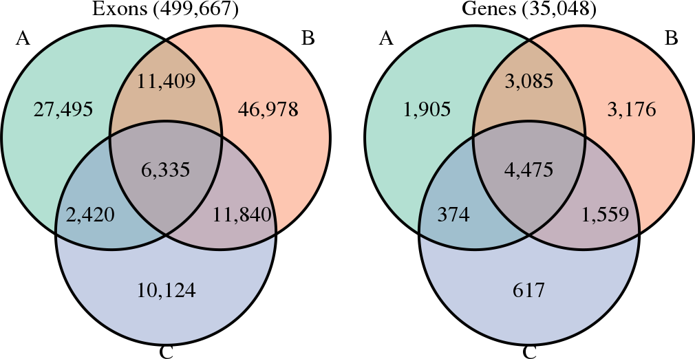

```r
venn.plot.genes <- venn.diagram(
    allGenes, NULL,
    fill=c("#66c2a5", "#fc8d62", "#8da0cb"),
    main=sprintf("Genes (%s)", format(length(unique( multiExonicGenes)),
        big.mark=",", scientific=FALSE) ) )
venn.plot.genes <- formatNumbersInVenn(venn.plot.genes)

gl <- grid.layout(nrow=1, ncol=2)
vp.1 <- viewport(layout.pos.col=1, layout.pos.row=1)
vp.2 <- viewport(layout.pos.col=2, layout.pos.row=1)
pushViewport(viewport(layout=gl))
pushViewport(vp.1)
grid.draw(venn.plot)
popViewport()
pushViewport(vp.2)
grid.draw(venn.plot.genes)
popViewport(1)
```

Then, we get the number of exons with TDU in at least one of the subsets of the *GTEx* data.

```r
#sapply( allExons, function(x){ length(x) / numberExons } )

allExons <- unique( unlist(allExons) )


cat( sprintf( "Total number of DEU exons %s\n", length( allExons ) ) )
```

```
## Total number of DEU exons 116601
```

```r
cat( sprintf( "Total number of exons %s\n", numberExons ) )
```

```
## Total number of exons 499667
```

```r
cat( sprintf( "Percentage of DEU exons: %s\n",
                       round( 100 * length(allExons) / numberExons ) ) )
```

```
## Percentage of DEU exons: 23
```

We then plot the relation between the tissue score and the p-value. Subset B and C are plotted together and are included in the supplementary material.

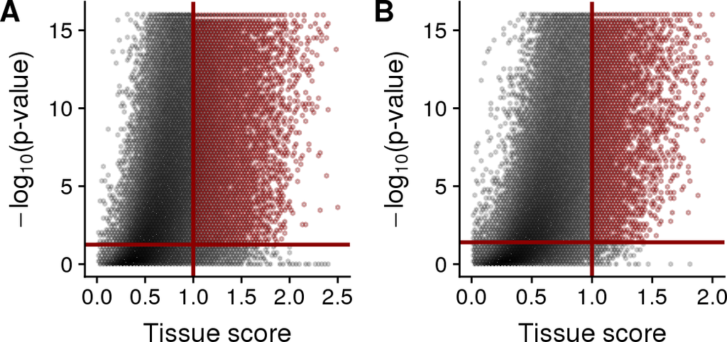

```r
effectSizeVsPval <- function( lab, xmax=1.5 ){
    resultsDF$pvalsTrans <- -log10( resultsDF$pvals )
    res <- filter(resultsDF, label==lab, mean > 10)
    res$col <- ifelse( res$padj < 0.1 & res$tdu > 1, "darkred", "#000010" )
    panel1 <- ggplot( res, aes(tdu, pvalsTrans, fill=col, col=col) ) +
        geom_hex( aes(alpha=log(..count..)),fill=c("#000000"), bins=75) +
        xlim(0, xmax) +
        scale_colour_manual(values=c("#00000030", "#8b000060")) +
        theme(legend.position="none") +
        geom_vline(xintercept = 1, lwd=1, col="darkred") +
        geom_hline(yintercept = min(res$pvalsTrans[which(res$padj < 0.1)], na.rm=TRUE),
                   lwd=1, col="darkred" ) +
        xlab("Tissue score") +
        ylab( expression(paste(-log[10], "(p-value)") ) )
    panel1
}

fig2PanelA <- effectSizeVsPval( "subsetA" )
effectSiS1 <- effectSizeVsPval( "subsetB", xmax=2.5)
effectSiS2 <- effectSizeVsPval( "subsetC", xmax=2)

sup2 <- plot_grid( effectSiS1, effectSiS2,
                  ncol=2, label_size = 16,
                  labels="AUTO" )

print(sup2)
```

For each gene, we estimate the number of exonic regions and the number of base pairs of the union of its exonic regions.

```r
exonsPerGene <- as.data.frame(mcols(dxd1)) %>% dplyr:::count(groupID)
colnames(exonsPerGene)[2] <- "exons"
geneWidth <- tapply(
    width(SummarizedExperiment::rowRanges(dxd1)),
    groupIDs(dxd1), sum )
stopifnot( names( geneWidth ) == exonsPerGene$groupID )
exonsPerGene$geneWidth <- as.numeric( geneWidth )
```

Then, we estimate the fraction of exonic regions that are used in a tissue-dependent manner and the fraction of base pairs that are affected by TDU.

```r
addNumDeu <- function( exonsPerGene, num ){
    subset <- paste0( "subset", LETTERS[num] )
    colName <- paste0( "deuExons", LETTERS[num] )
    colName2 <- paste0("affectedBp", LETTERS[num])
    deuEx <- getDEUNumbers( subset, resultsDF, returnEx=TRUE )
    deuExGn <- sapply( strsplit( deuEx, ":" ), "[[", 1 )
    affectedWidth <- width( SummarizedExperiment::rowRanges( dxd1 )[deuEx] )
    affectedWidth <- tapply( affectedWidth, deuExGn, sum )
    deuPerGene <- table( deuExGn )
    exonsPerGene[[colName]] <- 0
    exonsPerGene[[colName]][match( names(deuPerGene), exonsPerGene$groupID )] <- deuPerGene
    exonsPerGene[[paste0("fracAffectedExons", LETTERS[num])]] <-
        exonsPerGene[[colName]] / exonsPerGene$exons
    exonsPerGene[[colName2]] <- 0
    exonsPerGene[[colName2]][match( names(affectedWidth), exonsPerGene$groupID )] <- affectedWidth
    exonsPerGene[[paste0("fracAffectedBp", LETTERS[num])]] <-
        exonsPerGene[[colName2]] / exonsPerGene$geneWidth
    exonsPerGene
}

addGeneExpr <- function( exonsPerGene, num ){
    dsd <- get( paste0( "dsd", num ) )
    dsd <- estimateSizeFactors( dsd )
    geneMeans <- rowMeans( counts( dsd, normalized=TRUE) )
    colName <- paste0( "mean", LETTERS[num] )
    exonsPerGene[[colName]] <-
        geneMeans[match( exonsPerGene$groupID, names(geneMeans) )]
    exonsPerGene
}

for( i in 1:3 ){
    exonsPerGene <- addGeneExpr( exonsPerGene, i )
    exonsPerGene <- addNumDeu( exonsPerGene, i )
}
```

```
## subsetA has 47659 DEU exons that correspond to 9839 genes
## subsetB has 76562 DEU exons that correspond to 12295 genes
## subsetC has 30719 DEU exons that correspond to 7025 genes
```

```r
exonsPerGene <- as.data.frame(exonsPerGene)
rownames(exonsPerGene) <- exonsPerGene$groupID

backFile <- file.path( path, "geneBackgrounds.RData" )

if( file.exists( backFile ) ){
    load( backFile )
}else{
    backgroundList <- lapply( c("A", "B", "C"),
        function(x){
            frm <- as.formula( paste( "sign ~ exons +", paste0( "mean", x ) ) )
            df <- exonsPerGene
            df$sign <- as.numeric( df$deuExonsA > 0 )
            set.seed(100)
            mm <- matchit( frm, df, meathod="nearest", distance="mahalanobis" )$match.matrix[,1]
            mm
        } )
    names(backgroundList) <- c("subsetA", "subsetB", "subsetC")
}
```

```r
table1 <- sapply( c("A", "B", "C"),
                 function(x){
                     mean <- paste0( "mean", x )
                     deuExons <- paste0( "deuExons", x )
                     expressed <- table( exonsPerGene$exons > 1 & exonsPerGene[,mean] > 100 )["TRUE"]
                     deuExpressed <- table(
                         exonsPerGene$exons > 1 &
                         exonsPerGene[,deuExons] > 0 &
                         exonsPerGene[,mean] > 100 )["TRUE"]
                     c( `Expressed (> 100 counts)`=expressed,
                        `Expressed and TDU`=deuExpressed,
                        `Percentage`=round(deuExpressed/expressed*100) )
                 })
rownames(table1) <- gsub(".TRUE", "", rownames(table1))
colnames(table1) <- paste("Subset", colnames( table1 ))
table1
```

```
##                          Subset A Subset B Subset C
## Expressed (> 100 counts)    13535    13816    13205
## Expressed and TDU            8741    10388     6124
## Percentage                     65       75       46
```